# CP04- Ventas de Apple

Gonzalo Rodríguez Cañada

2020-11-16

# Objetivo

# Cargamos las librerias y los datos

```r
library(dplyr) #To efficiently manipulate dataframes.
library(xts) #To work with extensible Time Series
require(ggplot2) #To build better graphs
library(forecast) #To use Holt (among others) models
library(urca)
library(ggfortify)
```

# Análisis del conjunto de datos

```r
apple <- read.csv("IngresosApple.csv", sep=";")

skimr::skim(apple)
```

[output not shown]

# Hacemos una fila con la fecha de los trimestres

Con el objetivo de ordenar los datos y poder transformarlos a formato xts se crean una columna con las fechas de los trimestres.

```r
fechas <- seq(as.Date("2008-04-01"), as.Date("2017-09-30"), by = "quarter")
fechas
apple <- mutate(apple, fecha=fechas)
str(apple)
```

[output not shown]

# Lo pasamos a formato xts

```r
#Formato xts ordenado por las fechas

Ventas=xts(apple$Ingresos, order.by = as.Date(apple$fecha,"%Y/%m/%d"),frequency=4)

#Generamos los datos de manera trimestral

Ventas=to.quarterly(Ventas)
```

# Formato zoo y graficamos

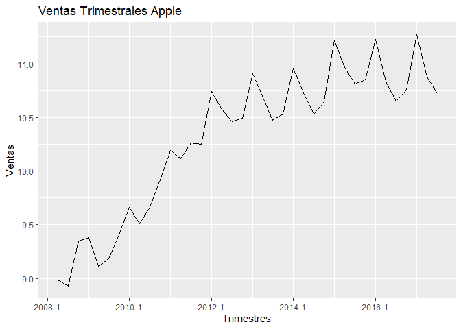

```r
#Formato zoo
zVentas=as.zoo(Ventas$Ventas.Close)
zVentas<-log(zVentas)
#Graficamos
autoplot(zVentas)+ggtitle("Ventas Trimestrales Apple")+xlab("Trimestres")+ylab("Ventas")
```

Observamos que no es estacionario ni en media ni en varianza.

- Representamos estos mismos datos pero de manera trimestral

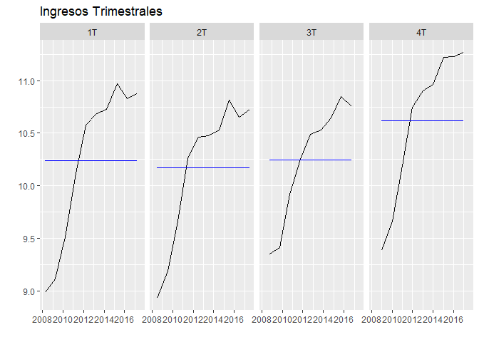

Donde el T1 corresponde al primer trimestre de todos los años de la muestra, T2 al segundo trimestre y viceversa. Como se observa en el cuarto cuatrimestre, la media de ingresos es mayor debido al lanzamiento de productos.

# Creamos la submuestra

Quitamos los cuatrimestres correspondientes a 2017.

# Modelo ETS

- Los modelos ETS son una familia de modelos de series temporales con un modelo de espacio de estado subyacente que consiste en un componente de nivel, un componente de tendencia (T), un componente estacional (S) y un término de error (E).

```
## [1] "ETS(M,A,A)"
```

```
##
## Forecast method: ETS(M,A,A)
##
## Model Information:
## ETS(M,A,A)
##
## Call:
##  ets(y = oVentas)
##
##   Smoothing parameters:
##     alpha = 0.4924
##     beta  = 0.3676
##     gamma = 0.5076
##
##   Initial states:
##     l = 9.0376
##     b = 0.0906
##     s = 0.1881 0.0807 -0.2048 -0.064
##
##   sigma:  0.0117
##
##         AIC        AICc         BIC
## -14.9459243  -7.7459243  -0.9477917
##
## Error measures:
##                        ME      RMSE        MAE         MPE      MAPE      MASE
## Training set -0.006606452 0.1059325 0.08553984 -0.06269475 0.8397395 0.3489455
##                     ACF1
## Training set 0.007074111
##
## Forecasts:
##         Point Forecast     Lo 80    Hi 80     Lo 95    Hi 95
## 2017 Q1       11.11778 10.950534 11.28502 10.862000 11.37356
## 2017 Q2       10.82187 10.604626 11.03912 10.489623 11.15412
## 2017 Q3       10.69711 10.401017 10.99319 10.244277 11.14993
## 2017 Q4       10.77713 10.381404 11.17286 10.171919 11.38234
## 2018 Q1       11.14016 10.570250 11.71007 10.268556 12.01177
## 2018 Q2       10.84425 10.161066 11.52744  9.799408 11.88910
## 2018 Q3       10.71949  9.906558 11.53242  9.476220 11.96276
## 2018 Q4       10.79951  9.843115 11.75591  9.336827 12.26220
```

Así como el error medio, el error cuadrático medio y el MAPE que nos da una información similar a estos dos últimos.

## Graficamos los errores

Nos interesa que se asemejen a ruido blanco, como así podemos comprobarlo gráficamente, lo cual nos indica que vamos por buen camino y que nuestro modelo es correcto.

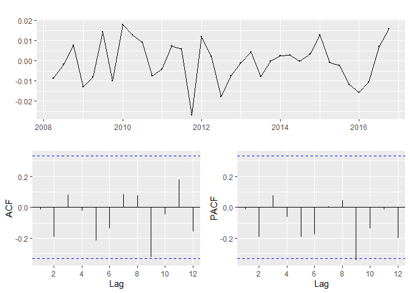

- Graficamos la predicción

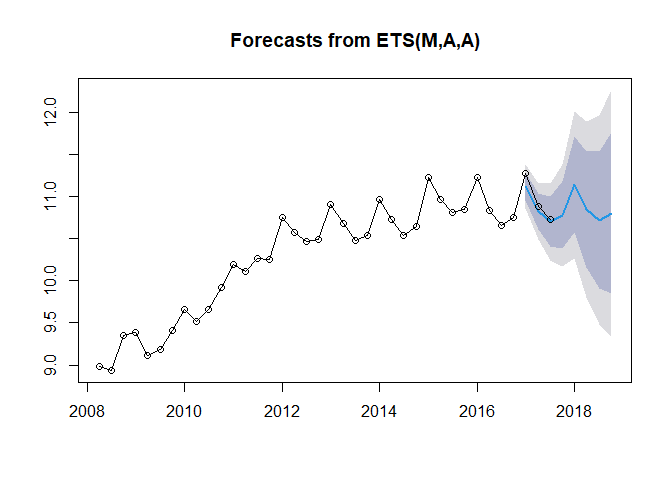

En este gráfico observamos que la línea de color negro es el valor real, mientras que la azul es la predicción , con los intervalos de confianza también en azul. De modo que nos hacemos una idea de la predicción de nuestro modelo.

# Modelo ARIMA

Quitamos los cuatrimestres correspondientes a 2017, como hicimos anteiormente.

Especificamos el modelo Arima, indicando que queremos que se trabaje con el valor de lambda igual a 0, que nos indica que se trabaja con el logartimo. Posteriormente, mostramos un resumen del mejor modelo Arima.

```
## Series: oVentas
## ARIMA(0,1,0)(0,1,0)[4]
## Box Cox transformation: lambda= 0
##
## sigma^2 estimated as 0.0001455:  log likelihood=90.04
## AIC=-178.08   AICc=-177.94   BIC=-176.68
##
## Training set error measures:
##                        ME      RMSE        MAE         MPE      MAPE      MASE
## Training set -0.009433358 0.1149941 0.08310241 -0.08075189 0.8077781 0.3390024
##                    ACF1
## Training set -0.1045467
```

## Graficamos los residuos.

Nos interesa que los errores sean ruido blanco, como se observa gráficamente.

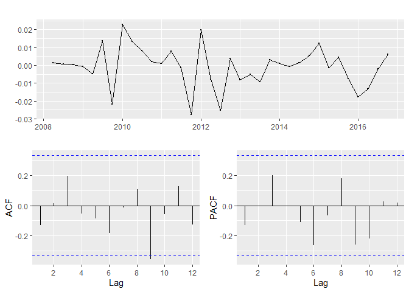

Creamos un data frame de los valores con dos columnas, en donde time es la correspondiente a los trimestres y value son los ingresos.

## Hacemos la predicción y graficamos

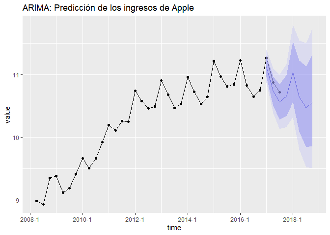

En este gráfico observamos que la línea de color negro es el valor real, mientras que la azul es la predicción , con los intervalos de confianza también en azul. De modo que nos hacemos una idea de la predicción de nuestro modelo.

- Aqui mostramos un resumen de las predicciones del mejor modelo ARIMA.

```
##
## Forecast method: ARIMA(0,1,0)(0,1,0)[4]
##
## Model Information:
## Series: oVentas
## ARIMA(0,1,0)(0,1,0)[4]
## Box Cox transformation: lambda= 0
##
## sigma^2 estimated as 0.0001455:  log likelihood=90.04
## AIC=-178.08   AICc=-177.94   BIC=-176.68
##
## Error measures:
##                        ME      RMSE        MAE         MPE      MAPE      MASE
## Training set -0.009433358 0.1149941 0.08310241 -0.08075189 0.8077781 0.3390024
##                    ACF1
## Training set -0.1045467
##
## Forecasts:
##         Point Forecast     Lo 80    Hi 80     Lo 95    Hi 95
## 2017 Q1       11.13163 10.960855 11.30507 10.871514 11.39797
## 2017 Q2       10.73641 10.504213 10.97374 10.383335 11.10149
## 2017 Q3       10.56101 10.281957 10.84764 10.137232 11.00250
## 2017 Q4       10.66097 10.336364 10.99576 10.168550 11.17723
## 2018 Q1       11.03456 10.562433 11.52780 10.320736 11.79776
## 2018 Q2       10.64279 10.087791 11.22832  9.805807 11.55121
## 2018 Q3       10.46892  9.841112 11.13677  9.524159 11.50739
## 2018 Q4       10.56800  9.862005 11.32454  9.507570 11.74671
```

## Conclusiones

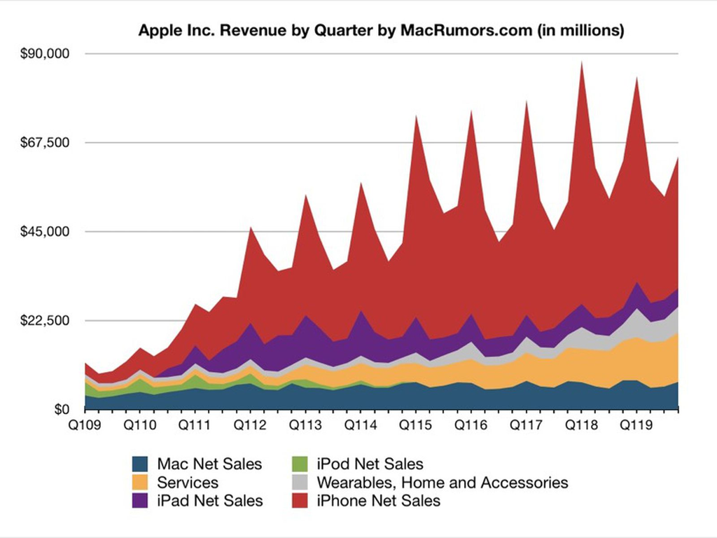

En este gráfico observamos los ingresos por dispositivo para la compañía Apple, donde merece la pena destcar con gran parte de los beneficios obtenidos por este gigante,provienen del iPhone , el cual aumenta sus beneficios conforme pasan los años,no obstante también se observa que a medida que transcurre el año se llega a un pico y después se disminuye, esto se puede deber a la salida al mercado de los iPhones y iPads, que en el primer caso es sobre septiembre y en el segundo en marzo, donde los ingresos aumentan considerablemente a la salida y posteriormente caen.